# hotel

```python
import pandas as pd
import numpy as np
import matplotlib.pyplot as plt
import statsmodels.api as sm

from sklearn.model_selection import train_test_split
from sklearn.preprocessing import MinMaxScaler, LabelEncoder, StandardScaler
from sklearn.linear_model import LogisticRegression
from sklearn.discriminant_analysis import LinearDiscriminantAnalysis as LDA
from sklearn.decomposition import PCA, KernelPCA as KPCA
from sklearn.svm import SVC
from imblearn.over_sampling import SMOTE
from sklearn.metrics import classification_report
from sklearn.tree import DecisionTreeClassifier as DTree, plot_tree
from sklearn.ensemble import RandomForestClassifier as RF, VotingClassifier
from sklearn.naive_bayes import GaussianNB
from sklearn.neighbors import KNeighborsClassifier as KNN
# from mlxtend.feature_selection import SequentialFeatureSelector as SFS
```

```python
df = pd.read_csv('data/Hotel Reservations.csv')
df.head()
```

|  | Booking_ID | no_of_adults | no_of_children | no_of_weekend_nights | no_of_week_nights | type_of_meal_plan | required_car_parking_space | room_type_reserved | lead_time | arrival_year | arrival_month | arrival_date | market_segment_type | repeated_guest | no_of_previous_cancellations | no_of_previous_bookings_not_canceled | avg_price_per_room | no_of_special_requests | booking_status |
| --- | --- | --- | --- | --- | --- | --- | --- | --- | --- | --- | --- | --- | --- | --- | --- | --- | --- | --- | --- |
| 0 | INN00001 | 2 | 0 | 1 | 2 | Meal Plan 1 | 0 | Room_Type 1 | 224 | 2017 | 10 | 2 | Offline | 0 | 0 | 0 | 65.00 | 0 | Not_Canceled |
| 1 | INN00002 | 2 | 0 | 2 | 3 | Not Selected | 0 | Room_Type 1 | 5 | 2018 | 11 | 6 | Online | 0 | 0 | 0 | 106.68 | 1 | Not_Canceled |
| 2 | INN00003 | 1 | 0 | 2 | 1 | Meal Plan 1 | 0 | Room_Type 1 | 1 | 2018 | 2 | 28 | Online | 0 | 0 | 0 | 60.00 | 0 | Canceled |
| 3 | INN00004 | 2 | 0 | 0 | 2 | Meal Plan 1 | 0 | Room_Type 1 | 211 | 2018 | 5 | 20 | Online | 0 | 0 | 0 | 100.00 | 0 | Canceled |
| 4 | INN00005 | 2 | 0 | 1 | 1 | Not Selected | 0 | Room_Type 1 | 48 | 2018 | 4 | 11 | Online | 0 | 0 | 0 | 94.50 | 0 | Canceled |

```python
# unprocessed data
df.info()
```

```
<class 'pandas.core.frame.DataFrame'>
RangeIndex: 36275 entries, 0 to 36274
Data columns (total 19 columns):
 #   Column                                Non-Null Count  Dtype
---  ------                                --------------  -----
 0   Booking_ID                            36275 non-null  object
 1   no_of_adults                          36275 non-null  int64
 2   no_of_children                        36275 non-null  int64
 3   no_of_weekend_nights                  36275 non-null  int64
 4   no_of_week_nights                     36275 non-null  int64
 5   type_of_meal_plan                     36275 non-null  object
 6   required_car_parking_space            36275 non-null  int64
 7   room_type_reserved                    36275 non-null  object
 8   lead_time                             36275 non-null  int64
 9   arrival_year                          36275 non-null  int64
 10  arrival_month                         36275 non-null  int64
 11  arrival_date                          36275 non-null  int64
 12  market_segment_type                   36275 non-null  object
 13  repeated_guest                        36275 non-null  int64
 14  no_of_previous_cancellations          36275 non-null  int64
 15  no_of_previous_bookings_not_canceled  36275 non-null  int64
 16  avg_price_per_room                    36275 non-null  float64
 17  no_of_special_requests                36275 non-null  int64
 18  booking_status                        36275 non-null  object
dtypes: float64(1), int64(13), object(5)
memory usage: 5.3+ MB
```

## -----------data processing begins -------

```python
# recode target column, 1 = canceled, 0 = not canceled
df.booking_status = np.where(df.booking_status == "Not_Canceled", 0, 1)
df.booking_status.value_counts()
```

```
0    24390
1    11885
Name: booking_status, dtype: int64
```

```python
# create a variable named arrival_season based on month
# and drop arrival date, year, months since we have lead time
df = df.assign(
    arrival_season = np.select(
        [
            df["arrival_month"].isin([12, 1, 2]),
            df["arrival_month"].isin([3, 4, 5]),
            df["arrival_month"].isin([6, 7, 8]),
            df["arrival_month"].isin([9, 10, 11])
        ],
        ["winter", "spring", "summer", "fall"]
    )
)

### the season variable is improving the accuracy

# booking id only vs arrival date, month , year
df.drop(columns=["Booking_ID", "arrival_month", "arrival_date", "arrival_year"], axis=1, inplace=True)

# one hot encode
df = pd.get_dummies(data=df, columns=["room_type_reserved","type_of_meal_plan", "market_segment_type", "arrival_season"], drop_first=False)
```

```python
# processed data
df.info()
```

```
<class 'pandas.core.frame.DataFrame'>
RangeIndex: 36275 entries, 0 to 36274
Data columns (total 32 columns):
 #   Column                                Non-Null Count  Dtype
---  ------                                --------------  -----
 0   no_of_adults                          36275 non-null  int64
 1   no_of_children                        36275 non-null  int64
 2   no_of_weekend_nights                  36275 non-null  int64
 3   no_of_week_nights                     36275 non-null  int64
 4   required_car_parking_space            36275 non-null  int64
 5   lead_time                             36275 non-null  int64
 6   repeated_guest                        36275 non-null  int64
 7   no_of_previous_cancellations          36275 non-null  int64
 8   no_of_previous_bookings_not_canceled  36275 non-null  int64
 9   avg_price_per_room                    36275 non-null  float64
```

[output cut: 24 more lines]

```python
df.booking_status.value_counts()
# target is imbalanced, would need to over sample with SMOTE
```

```
0    24390
1    11885
Name: booking_status, dtype: int64
```

```python
# with pd.option_context("display.max_rows", 500, "display.max_columns", None):
#     display(df.head(100))
```

```python
# features
df.drop(columns="booking_status", axis=1).info(verbose=True)
```

```
<class 'pandas.core.frame.DataFrame'>
RangeIndex: 36275 entries, 0 to 36274
Data columns (total 31 columns):
 #   Column                                Non-Null Count  Dtype
---  ------                                --------------  -----
 0   no_of_adults                          36275 non-null  int64
 1   no_of_children                        36275 non-null  int64
 2   no_of_weekend_nights                  36275 non-null  int64
 3   no_of_week_nights                     36275 non-null  int64
 4   required_car_parking_space            36275 non-null  int64
 5   lead_time                             36275 non-null  int64
 6   repeated_guest                        36275 non-null  int64
 7   no_of_previous_cancellations          36275 non-null  int64
 8   no_of_previous_bookings_not_canceled  36275 non-null  int64
 9   avg_price_per_room                    36275 non-null  float64
```

[output cut: 23 more lines]

```python
# convert to numpy and split data
X = df.drop(columns="booking_status", axis=1).to_numpy()
y = df.booking_status.to_numpy()
```

```python
# split
X_train, X_test, y_train, y_test = train_test_split(X, y, test_size=0.3, random_state=42, stratify=y)

df_list = [X_train, X_test, y_train, y_test]
obj_names = ["X_train", "X_test", "y_train", "y_test"]

for d, name in zip(df_list, obj_names):
    print(name, d.shape)
```

```
X_train (25392, 31)
X_test (10883, 31)
y_train (25392,)
y_test (10883,)
```

```python
# scale data
scaler = StandardScaler()
# scaler = MinMaxScaler() # better with PCA on all features? -> no, it does poor job
X_train = scaler.fit_transform(X_train)
X_test = scaler.transform(X_test)
```

```python
# oversample with SMOTE
sampler = SMOTE(random_state=42)

X_train_new, y_train_new = sampler.fit_resample(X_train, y_train)
```

```python
val, cnt = np.unique(y_train_new, return_counts=True)
print("y_train_new class counts:", dict(zip(val, cnt)))
```

```
y_train_new class counts: {0: 17073, 1: 17073}
```

### -----------------------data processing ends--------------------------------

### ---------------feature selection begins--------------

## Logistic regression

### use all 31 features

```python
# fit logistic regression on all features
lr_obj_all = LogisticRegression(random_state=42)
lr_obj_all.fit(X_train_new, y_train_new)

y_pred = lr_obj_all.predict(X_test)
print("Logistic regression Accuracy (with all features):", lr_obj_all.score(X_test, y_test))
# print(classification_report(y_test, y_pred))
```

```
Logistic regression Accuracy (with all features): 0.7801157768997519
```

### LDA

```python
# use LDA to reduce number of features
lda_obj = LDA()
lda_obj.fit(X_train_new, y_train_new)
```

```
LinearDiscriminantAnalysis()
```

```python
X_train_lda = lda_obj.transform(X_train_new)
X_test_lda = lda_obj.transform(X_test)

print("X_train_lda.shape", X_train_lda.shape)
print("X_test_lda.shape", X_test_lda.shape)
```

```
X_train_lda.shape (34146, 1)
X_test_lda.shape (10883, 1)
```

```python
lr_lda_obj = LogisticRegression(random_state=42)
lr_lda_obj.fit(X_train_lda, y_train_new)
print("LDA accuracy:", lr_lda_obj.score(X_test_lda, y_test))
```

```
LDA accuracy: 0.7802076633281264
```

accruacy increased, LDA can only have number of classes - 1 components. try PCA instead

### do PCA

```python
# use PCA to reduce number of features (numbers did not decrease we have all 30 features)
pca_obj = PCA()
pca_obj.fit(X_train_new)

X_train_pca = pca_obj.transform(X_train_new)
X_test_pca = pca_obj.transform(X_test)

print("X_train_pca.shape", X_train_pca.shape)
print("X_test_pca.shape", X_test_pca.shape)
```

```
X_train_pca.shape (34146, 31)
X_test_pca.shape (10883, 31)
```

#### fit logistic regression after pca (on all features)

```python
# fit logistic regression after pca (on all 30 features)
lr_pca_all = LogisticRegression(random_state=42)
lr_pca_all.fit(X_train_pca, y_train_new)

y_pred = lr_pca_all.predict(X_test_pca)
print("Logistic regression Accuracy (pca with all features):", lr_pca_all.score(X_test, y_test))
# print(classification_report(y_test, y_pred))
```

```
Logistic regression Accuracy (pca with all features): 0.5818248644675181
```

#### check the variance ratio of the PCA features

```python
exp_var_ratio = pca_obj.explained_variance_ratio_
exp_var_ratio.cumsum()
```

```
array([0.1137229 , 0.192457  , 0.26652843, 0.3298409 , 0.38230931,
       0.43404268, 0.48141313, 0.52249461, 0.56201468, 0.59857113,
       0.63485227, 0.66919109, 0.70207433, 0.73209942, 0.76055999,
       0.78801196, 0.81506482, 0.8412392 , 0.86679567, 0.8920336 ,
       0.91552487, 0.93659455, 0.95550858, 0.96901959, 0.97975817,
       0.99019522, 1.        , 1.        , 1.        , 1.        ,
       1.        ])
```

```python
feat_to_keep = np.where(exp_var_ratio.cumsum() <= 0.95)
feat_to_keep[0]
```

```
array([ 0,  1,  2,  3,  4,  5,  6,  7,  8,  9, 10, 11, 12, 13, 14, 15, 16,
       17, 18, 19, 20, 21])
```

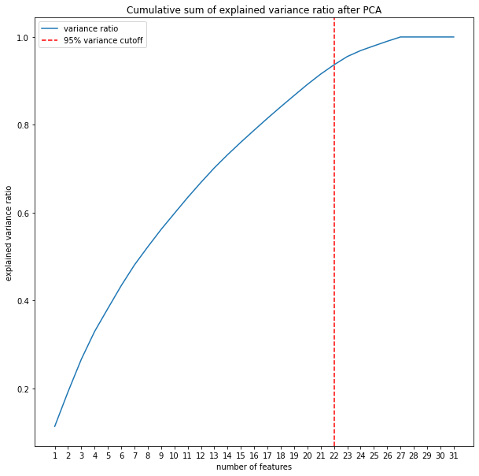

```python
# explained variance ratio plot
plt.figure(figsize=(10,10))
plt.plot(list(range(1, len(exp_var_ratio)+1)), exp_var_ratio.cumsum(), label="variance ratio")
plt.axvline(x=len(feat_to_keep[0]), color='r', ls="--", label='95% variance cutoff')
plt.xticks(list(range(1, len(exp_var_ratio)+1)))
plt.xlabel("number of features")
plt.ylabel("explained variance ratio")
plt.title("Cumulative sum of explained variance ratio after PCA")
plt.legend()
plt.savefig("pix/cumsum explained variance ratio after pca.png", dpi=200)
plt.show()
```

#### The first 22 features seem to capture majority of the variabilities. Keep the first 22 features

```python
X_train_pca = X_train_pca[:, :len(feat_to_keep[0])]
X_test_pca = X_test_pca[:, :len(feat_to_keep[0])]

print("X_train_pca.shape", X_train_pca.shape)
print("X_test_pca.shape", X_test_pca.shape)
```

```
X_train_pca.shape (34146, 22)
X_test_pca.shape (10883, 22)
```

### Logistic regression with PCA 22 features

```python
# fit logistic regresion
lr_pca_22 = LogisticRegression(random_state = 42)
lr_pca_22.fit(X_train_pca, y_train_new)

print(f"logistic regression pca with {len(feat_to_keep[0])} features:", lr_pca_22.score(X_test_pca, y_test))
```

```
logistic regression pca with 22 features: 0.7817697326104934
```

it is possible to get the same accuracy after PCA (dont run KPCA it takes forever to run)

### Backward elimination using logsitic regression

#### Start with a feature matrix (31 features)

#### then add a column of ones for the intercept

```python
# backward elimination on logisitc regression
# fit logistic regression on scaled data
# non pca
# append array of ones
X_one = np.concatenate([np.ones((len(X_train_new),1)), X_train_new], axis=1)
```

```python
# define a function to perform backward elimination
# sm.Logit obj has pvalues and use that info to eliminate variables
def backward_elimination(x: np.ndarray, y: np.ndarray, s: float) -> np.ndarray:
    """
    x: feature matrix
    y: target column
    s: significance level
    """
    # check if the first column is an array of ones with len == len(x)
    # if true then use the x that was input
    # if not true then append column of ones in front

    if np.all(x[:, 0] == 1):
        pass
    else:
        x = np.concatenate([np.ones((len(x), 1)), x], axis=1)


    n_variables = list(range(len(x[0])))

    # convert to dataframe and assign variable names
    y_df = pd.Series(data=y, name="target")
    cols = list(map(lambda n: "x"+ str(n), n_variables))
    x_df = pd.DataFrame(data=x, columns=cols)

    # to store indicies
    records = np.array(n_variables)

    for i in range(len(n_variables)):
        logit = sm.Logit(y_df, x_df).fit()
        pvalues = logit.pvalues
        max_p = max(pvalues)
        max_p_index = pvalues.argmax()
        if max_p > s:
            x_df = x_df.drop(columns=x_df.columns[max_p_index], axis=1)
            records = np.delete(records, max_p_index)
        else:
            break

    print(logit.summary())

    # drop intercept index; indicies - 1 to offset so it matches the variable shape
    records = np.delete(records, 0) - 1

    print("remaining variable indices", records)

    # convert to numpy and drop intercept column from x_df
    return (x_df.to_numpy()[:, 1:], records.tolist())

# resulting feature matrix and indicies
X_train_be, indicies = backward_elimination(X_train_new, y_train_new, 0.05)

# update X_test
X_test_be = X_test[:, indicies]

print("X_train_be.shape:", X_train_be.shape)
print("X_test_be.shape:", X_test_be.shape)
```

```
Optimization terminated successfully.
         Current function value: 0.457238
         Iterations 11
Optimization terminated successfully.
         Current function value: 0.457238
         Iterations 11
Optimization terminated successfully.
         Current function value: 0.457240
         Iterations 11
Optimization terminated successfully.
         Current function value: 0.457241
         Iterations 11
Optimization terminated successfully.
         Current function value: 0.457250
         Iterations 11
Optimization terminated successfully.
         Current function value: 0.457284
         Iterations 9
Optimization terminated successfully.
         Current function value: 0.457303
         Iterations 9
                           Logit Regression Results
==============================================================================
Dep. Variable:                 target   No. Observations:                34146
Model:                          Logit   Df Residuals:                    34126
Method:                           MLE   Df Model:                           19
Date:                Mon, 24 Apr 2023   Pseudo R-squ.:                  0.3403
Time:                        18:14:31   Log-Likelihood:                -15615.
converged:                       True   LL-Null:                       -23668.
Covariance Type:            nonrobust   LLR p-value:                     0.000
==============================================================================
                 coef    std err          z      P>|z|      [0.025      0.975]
------------------------------------------------------------------------------
x0            -0.4701      0.017    -26.969      0.000      -0.504      -0.436
x2             0.0524      0.020      2.667      0.008       0.014       0.091
x3             0.1694      0.014     11.875      0.000       0.141       0.197
x4             0.0563      0.014      3.911      0.000       0.028       0.085
x5            -0.2632      0.018    -14.438      0.000      -0.299      -0.227
x6             1.3867      0.019     72.956      0.000       1.349       1.424
x7            -0.4518      0.063     -7.128      0.000      -0.576      -0.328
x8             0.0797      0.025      3.130      0.002       0.030       0.130
x10            0.5554      0.020     27.217      0.000       0.515       0.595
x11           -1.1917      0.019    -62.320      0.000      -1.229      -1.154
x12            0.0713      0.017      4.226      0.000       0.038       0.104
x16           -0.0445      0.015     -3.005      0.003      -0.074      -0.015
x17           -0.0788      0.020     -3.956      0.000      -0.118      -0.040
x18           -0.0780      0.018     -4.425      0.000      -0.113      -0.043
x22            0.0895      0.015      5.932      0.000       0.060       0.119
x23            0.0968      0.013      7.678      0.000       0.072       0.122
x25            0.2175      0.019     11.275      0.000       0.180       0.255
x27            0.9185      0.020     46.042      0.000       0.879       0.958
x29            0.0447      0.014      3.176      0.001       0.017       0.072
x31           -0.2381      0.017    -13.618      0.000      -0.272      -0.204
==============================================================================
remaining variable indices [ 1  2  3  4  5  6  7  9 10 11 15 16 17 21 22 24 26 28 30]
X_train_be.shape: (34146, 19)
X_test_be.shape: (10883, 19)
```

#### Fit logstic regression on resulting matrix

#### variables remaining after backward elimination (19 variables):

1. x2: no_of_children
2. x3: no_of_weekend_nights
3. x4: no_of_week_nights
4. x5: required_car_parking_space
5. x6: lead_time
6. x7: repeated_guest
7. x8: no_of_previous_cancellations
8. x10: avg_price_per_room
9. x11: no_of_special_requests
10. x12: room_type_reserved_Room_Type 1
11. x16: room_type_reserved_Room_Type 5
12. x17: room_type_reserved_Room_Type 6
13. x18: room_type_reserved_Room_Type 7
14. x22: type_of_meal_plan_Not Selected
15. x23: market_segment_type_Aviation
16. x25: market_segment_type_Corporate
17. x27: market_segment_type_Online
18. x29: arrival_season_spring
19. x31:arrival_season_winter

** we will use these list for variables for other models

```python
# # verify the results
# # backward elimination on pandas data frame (to see variable names)
# x_df = df.drop(columns="booking_status", axis=1)
# y_df = df.booking_status

# # # train test split
# x_df_train, x_df_test, y_df_train, y_df_test = train_test_split(x_df, y_df, test_size=0.3, random_state=42, stratify=y)

# # scale data
# # scaled_x_train_df = pd.DataFrame(X_train, index=x_df_train.index, columns=x_df_train.columns)
# scaled_x_test_df = pd.DataFrame(X_test, index=x_df_test.index, columns=x_df_test.columns)

# # df after smote
# smote_x_train_df = pd.DataFrame(X_train_new, columns=x_df.columns)
# smote_y_train_df = pd.Series(y_train_new, name="booking_status")

# # add intercept column to smote x train
# smote_x_train_df["intercept"] = 1
# # reorder columns
# cols = ["intercept", 'no_of_children', 'no_of_weekend_nights', 'no_of_week_nights', 'required_car_parking_space', 'lead_time', 'repeated_guest', 'no_of_previous_cancellations', 'avg_price_per_room', 'no_of_special_requests', 'room_type_reserved_Room_Type 1', 'room_type_reserved_Room_Type 5', 'room_type_reserved_Room_Type 6', 'type_of_meal_plan_Not Selected', 'market_segment_type_Aviation', 'market_segment_type_Corporate', 'market_segment_type_Online', 'arrival_season_spring', 'arrival_season_winter']
# smote_x_train_df = smote_x_train_df.reindex(columns=cols)

# # fit logistic regression
# logit2 = sm.Logit(smote_y_train_df, smote_x_train_df).fit()
# logit2.summary()
```

### ----------- data processing ends-----------

1. `X_train_new`; `X_test` has all 31 features (no feature selection)
2. `X_train_pca`; `X_test_pca` has 22 features from PCA
3. `X_train_be`; `X_test_be` has 19 features from backward elimination

**use `y_train_new` for fitting models and `y_test` for making predictions/calculate accuracy for all models**

## Logistic regression with 19 features from backward elimination

```python
# fit logistic regresion
lr_be = LogisticRegression(random_state = 42)
lr_be.fit(X_train_be, y_train_new)

print("logistic regression backward elimiation with 19 features:", lr_be.score(X_test_be, y_test))
```

```
logistic regression backward elimiation with 19 features: 0.7794725719011302
```

### 2D PCA to visualize

```python
pca_obj2 = PCA(n_components=2)
X_train_pca2 = pca_obj2.fit_transform(X_train_new)
X_test_pca2 = pca_obj2.transform(X_test)
```

```python
# fit logistic regression
lr_pca2 = LogisticRegression(random_state=42)
lr_pca2.fit(X_train_pca2, y_train_new)

print(lr_pca2.score(X_test_pca2, y_test))
```

```
0.647615547183681
```

```python
# # visualize the pca values
# plt.figure(figsize=(10,10))
# scatter = plt.scatter(x=X_train_pca2[:,0], y=X_train_pca2[:,1], c=y_train_new)
# plt.legend(*scatter.legend_elements())
# plt.show()
```

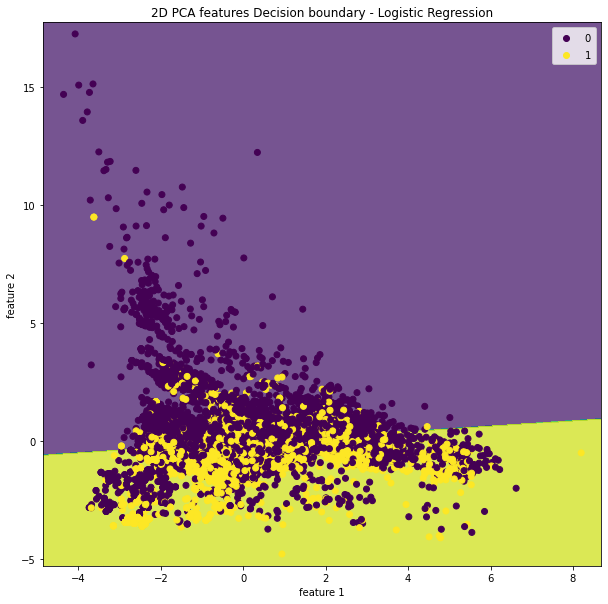

```python
# plot the decision boundary
# create a meshgrid to assign a color to each point
# step size
h = 0.02
x_min, x_max = X_test_pca2[:,0].min() - 0.5, X_test_pca2[:,0].max() + 0.5
y_min, y_max = X_test_pca2[:,1].min() - 0.5, X_test_pca2[:,1].max() + 0.5
xx, yy = np.meshgrid(np.arange(x_min, x_max, h), np.arange(y_min, y_max, h))

# create predictions
Z_pca = lr_pca2.predict(np.c_[xx.ravel(), yy.ravel()])

# put the result into a color plot
Z_pca = Z_pca.reshape(xx.shape)
plt.figure(figsize=(10,10))
plt.contourf(xx, yy, Z_pca, alpha=0.75)

# plot the test poins
scatter = plt.scatter(x=X_test_pca2[:,0], y=X_test_pca2[:,1], c=y_test)
plt.legend(*scatter.legend_elements())
plt.title("2D PCA features Decision boundary - Logistic Regression")
plt.xlabel("feature 1")
plt.ylabel("feature 2")
plt.savefig("pix/2d_pca_decision_boundary-logit.png", dpi=200)
plt.show()
```

## SVM with rbf

#### all 31 features

```python
# fit support vector machine
svm_rbf_all = SVC(kernel="rbf")
svm_rbf_all.fit(X_train_new, y_train_new)

print("X_train_new.shape", X_train_new.shape)
print("SVM - rbf Accuracy (with all features):", svm_rbf_all.score(X_test, y_test))
```

```
X_train_new.shape (34146, 31)
SVM - rbf Accuracy (with all features): 0.8164109161076909
```

#### pca 22 features

```python
# fit support vector machine
svm_rbf_pca = SVC(kernel="rbf")
svm_rbf_pca.fit(X_train_pca, y_train_new)

print("X_train_pca.shape", X_train_pca.shape)
print("SVM - rbf Accuracy (with 22 features):", svm_rbf_pca.score(X_test_pca, y_test))
```

```
X_train_pca.shape (34146, 22)
SVM - rbf Accuracy (with 22 features): 0.8109896168335937
```

#### Backward elimination 19 features

```python
# fit support vector machine
svm_rbf_be = SVC(kernel="rbf")
svm_rbf_be.fit(X_train_be, y_train_new)

print("X_train_be.shape", X_train_be.shape)
print("SVM -rbf Accuracy (with 19 features):", svm_rbf_be.score(X_test_be, y_test))
```

```
X_train_be.shape (34146, 19)
SVM -rbf Accuracy (with 19 features): 0.7964715611504181
```

#### PCA 2 features to visualize

```python
# pca with 2 and visualize decision boundary
svm_rbf_pca2 = SVC(kernel="rbf")
svm_rbf_pca2.fit(X_train_pca2, y_train_new)

print("X_train_pca2.shape", X_train_pca2.shape)
print("SVM accuracy with 2 features:", svm_rbf_pca2.score(X_test_pca2, y_test))
```

```
X_train_pca2.shape (34146, 2)
SVM accuracy with 2 features: 0.6653496278599651
```

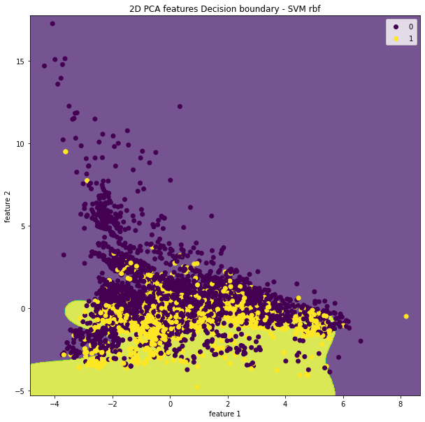

```python
# plot the decision boundary
# create a meshgrid to assign a color to each point
# step size
h = 0.02
x_min, x_max = X_test_pca2[:,0].min() - 0.5, X_test_pca2[:,0].max() + 0.5
y_min, y_max = X_test_pca2[:,1].min() - 0.5, X_test_pca2[:,1].max() + 0.5
xx, yy = np.meshgrid(np.arange(x_min, x_max, h), np.arange(y_min, y_max, h))

# create predictions
Z_rbf = svm_rbf_pca2.predict(np.c_[xx.ravel(), yy.ravel()])

# put the result into a color plot
Z_rbf = Z_rbf.reshape(xx.shape)
plt.figure(figsize=(10,10))
plt.contourf(xx, yy, Z_rbf, alpha=0.75)

# plot the test points
scatter = plt.scatter(x=X_test_pca2[:,0], y=X_test_pca2[:,1], c=y_test)
plt.legend(*scatter.legend_elements())
plt.title("2D PCA features Decision boundary - SVM rbf")
plt.xlabel("feature 1")
plt.ylabel("feature 2")
plt.savefig("pix/2d_pca_decision_boundary - SVM rbf.png")
plt.show()
```

## SVM with poly

#### all 31 features

```python
# fit support vector machine
svm_poly_all = SVC(kernel="poly")
svm_poly_all.fit(X_train_new, y_train_new)

print("X_train_new.shape", X_train_new.shape)
print("SVM - poly Accuracy (with all features):", svm_poly_all.score(X_test, y_test))
```

```
X_train_new.shape (34146, 31)
SVM - poly Accuracy (with all features): 0.8145731875402004
```

#### pca 22 features

```python
# fit support vector machine
svm_poly_pca = SVC(kernel="poly")
svm_poly_pca.fit(X_train_pca, y_train_new)

print("X_train_be.shape", X_train_pca.shape)
print("SVM - poly Accuracy (with 22 features):", svm_poly_pca.score(X_test_pca, y_test))
```

```
X_train_be.shape (34146, 22)
SVM - poly Accuracy (with 22 features): 0.8095194339796012
```

#### Backward elimination 19 features

```python
# fit support vector machine
svm_poly_be = SVC(kernel="poly")
svm_poly_be.fit(X_train_be, y_train_new)

print("X_train_be.shape", X_train_be.shape)
print("SVM - poly Accuracy (with 19 features):", svm_poly_be.score(X_test_be, y_test))
```

```
X_train_be.shape (34146, 19)
SVM - poly Accuracy (with 19 features): 0.7943581732978039
```

#### pca 2 features

```python
# pca with 2 and visualize decision boundary
svm_poly_obj1 = SVC(kernel="poly")
svm_poly_obj1.fit(X_train_pca2, y_train_new)

svm_poly_obj1.score(X_test_pca2, y_test)
```

```
0.6664522650004594
```

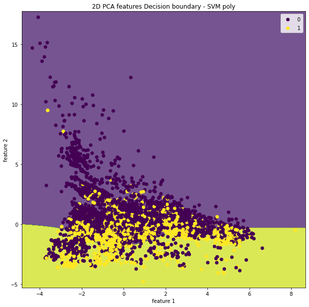

```python
# plot the decision boundary
# create a meshgrid to assign a color to each point
# step size
h = 0.02
x_min, x_max = X_test_pca2[:,0].min() - 0.5, X_test_pca2[:,0].max() + 0.5
y_min, y_max = X_test_pca2[:,1].min() - 0.5, X_test_pca2[:,1].max() + 0.5
xx, yy = np.meshgrid(np.arange(x_min, x_max, h), np.arange(y_min, y_max, h))

# create predictions
Z_poly = svm_poly_obj1.predict(np.c_[xx.ravel(), yy.ravel()])

# put the result into a color plot
Z_poly = Z_poly.reshape(xx.shape)
plt.figure(figsize=(10,10))
plt.contourf(xx, yy, Z_poly, alpha=0.75)

# plot the test poins
scatter = plt.scatter(x=X_test_pca2[:,0], y=X_test_pca2[:,1], c=y_test)
plt.title("2D PCA features Decision boundary - SVM poly")
plt.xlabel("feature 1")
plt.ylabel("feature 2")
plt.legend(*scatter.legend_elements())
plt.savefig("pix/2d_pca_decision_boundary - SVM poly.png")
plt.show()
```

## Decision Tree

### hyper parameter tunining for `max_depth` and `criterion`

#### goal is to find the combination of the value for `max_depth` and criterion `gini` vs `entropy` that gives highest accuracy

### create models and find accuracies

```python
depths = list(range(1, 31))
criterions = ["gini", "entropy"]
accuracy_gini_all_dc = []
accuracy_gini_pca_dc = []
accuracy_gini_be_dc = []
accuracy_entropy_all_dc = []
accuracy_entropy_pca_dc = []
accuracy_entropy_be_dc = []


for c in criterions:
    for d in depths:
        # all features
        tree_obj_all = DTree(max_depth = d, criterion=c, random_state=42)
        tree_obj_all.fit(X_train_new, y_train_new)
        if c == "gini":
            accuracy_gini_all_dc.append(tree_obj_all.score(X_test, y_test))
        else:
            accuracy_entropy_all_dc.append(tree_obj_all.score(X_test, y_test))

        # pca
        tree_obj_pca22 = DTree(max_depth=d, criterion=c, random_state=42)
        tree_obj_pca22.fit(X_train_pca, y_train_new)
        if c == "gini":
            accuracy_gini_pca_dc.append(tree_obj_pca22.score(X_test_pca, y_test))
        else:
            accuracy_entropy_pca_dc.append(tree_obj_pca22.score(X_test_pca, y_test))

        # backward elimination
        tree_obj_be = DTree(max_depth = d, criterion=c, random_state=42)
        tree_obj_be.fit(X_train_be, y_train_new)
        if c == "gini":
            accuracy_gini_be_dc.append(tree_obj_be.score(X_test_be, y_test))
        else:
            accuracy_entropy_be_dc.append(tree_obj_be.score(X_test_be, y_test))

# max depths
max_depth_gini_all = np.array(accuracy_gini_all_dc).argmax() + 1
max_depth_gini_pca = np.array(accuracy_gini_pca_dc).argmax() + 1
max_depth_gini_be = np.array(accuracy_gini_be_dc).argmax() + 1
max_depth_entropy_all = np.array(accuracy_entropy_all_dc).argmax() + 1
max_depth_entropy_pca = np.array(accuracy_entropy_pca_dc).argmax() + 1
max_depth_entropy_be = np.array(accuracy_entropy_be_dc).argmax() + 1

# max accuracies
max_acc_gini_all = max(accuracy_gini_all_dc)
max_acc_gini_pca = max(accuracy_gini_pca_dc)
max_acc_gini_be = max(accuracy_gini_be_dc)
max_acc_entropy_all = max(accuracy_entropy_all_dc)
max_acc_entropy_pca = max(accuracy_entropy_pca_dc)
max_acc_entropy_be = max(accuracy_entropy_be_dc)
```

### First compare `gini` vs `entropy`

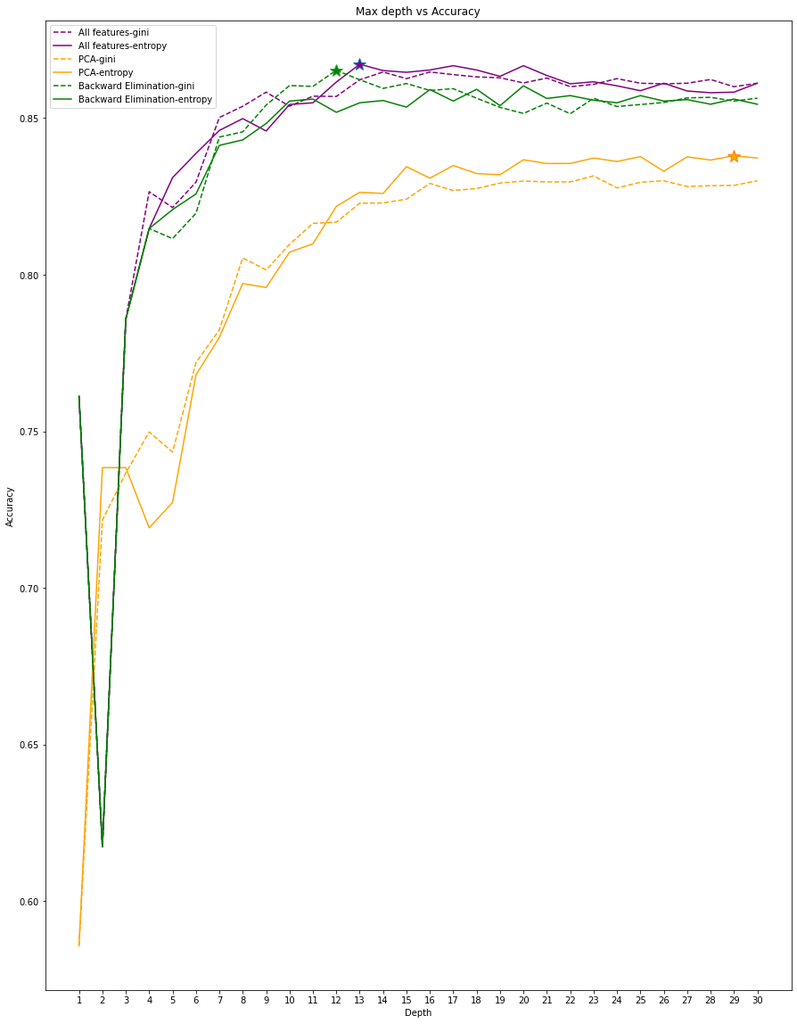

```python
# plot the trend
plt.figure(figsize=(15,20))

# lines
plt.plot(depths, accuracy_gini_all_dc, color="purple", ls="--", label="All features-gini")
plt.plot(depths, accuracy_entropy_all_dc, color="purple", label="All features-entropy")
plt.plot(max_depth_entropy_all, max_acc_entropy_all, marker="*", markersize=15, markerfacecolor="purple")

plt.plot(depths, accuracy_gini_pca_dc, color="orange", ls="--", label="PCA-gini")
plt.plot(depths, accuracy_entropy_pca_dc, color="orange", label="PCA-entropy")
plt.plot(max_depth_entropy_pca, max_acc_entropy_pca, marker="*", markersize=15, markerfacecolor="orange")

plt.plot(depths, accuracy_gini_be_dc, color="green", ls="--", label="Backward Elimination-gini")
plt.plot(depths, accuracy_entropy_be_dc, color="green", label="Backward Elimination-entropy")
plt.plot(max_depth_gini_be, max_acc_gini_be, marker="*", markersize=15, markerfacecolor="green")

# modify plot labels
plt.xticks(depths)
plt.xlabel("Depth")
plt.ylabel("Accuracy")
plt.title("Max depth vs Accuracy")
plt.legend(loc="upper left")#, bbox_to_anchor=(1.16, 0.5))
plt.savefig("pix/Decision_tree_accuracies_criterion.png", dpi=200, bbox_inches='tight')
plt.show()
```

#### all feature matrix: `entropy` has higher accuracy

#### PCA feature matrix: `entropy` has higher accuracy

#### backward elimination matrix: `gini` has higher accuracy

### Find the best value of `max_depth`

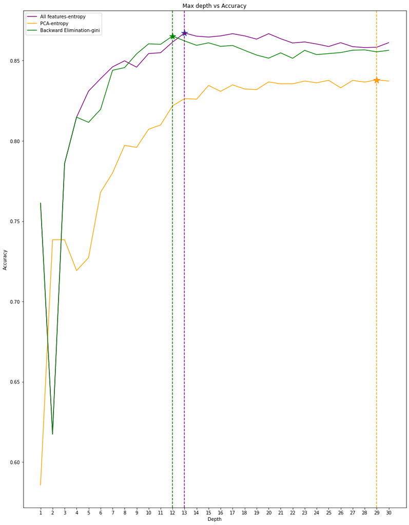

```python
# plot the trend
plt.figure(figsize=(15,20))

# lines
plt.plot(depths, accuracy_entropy_all_dc, color="purple", label="All features-entropy")
plt.plot(max_depth_entropy_all, max_acc_entropy_all, marker="*", markersize=15, markerfacecolor="purple")
plt.axvline(x=max_depth_entropy_all, color='purple', ls="--")

plt.plot(depths, accuracy_entropy_pca_dc, color="orange", label="PCA-entropy")
plt.plot(max_depth_entropy_pca, max_acc_entropy_pca, marker="*", markersize=15, markerfacecolor="orange")
plt.axvline(x=max_depth_entropy_pca, color='orange', ls="--")

plt.plot(depths, accuracy_gini_be_dc, color="green", label="Backward Elimination-gini")
plt.plot(max_depth_gini_be, max_acc_gini_be, marker="*", markersize=15, markerfacecolor="green")
plt.axvline(x=max_depth_gini_be, color='green', ls="--")

# modify plot labels
plt.xticks(depths)
plt.xlabel("Depth")
plt.ylabel("Accuracy")
plt.title("Max depth vs Accuracy")
plt.legend(loc="upper left")#, bbox_to_anchor=(1.16, 0.5))
plt.savefig("pix/Decision_tree_accuracies_max_depth.png", dpi=200, bbox_inches='tight')
plt.show()
```

#### all feature matrix: `max_depth=13`, `criterion='entropy'`

#### PCA feature matrix: `max_depth = 29`, `criterion='entropy'`

#### backward elimination feature matrix `max_depth = 12`, `criterion="gini"`

```python
######## all features ##############
print("Decision Tree with all features accuracy (max_depth=13, criterion=entropy):", max(accuracy_entropy_all_dc))

######## PCA ###############
print("Decision Tree with 22 features (PCA) accuracy (max_depth=29, criterion=entropy):", max(accuracy_entropy_pca_dc))

########## backward elimination ######
print("Decision Tree with 19 features (backward elimination) accuracy (max_depth=12, criterion=gini):", max(accuracy_gini_be_dc))
```

```
Decision Tree with all features accuracy (max_depth=13, criterion=entropy): 0.8672241109988055
Decision Tree with 22 features (PCA) accuracy (max_depth=29, criterion=entropy): 0.8380042267757052
Decision Tree with 19 features (backward elimination) accuracy (max_depth=12, criterion=gini): 0.8652944960029404
```

## Random Forest

### hyper parameter tuning: `n_estimators` and `criterion`

#### goal is to find the best value for `n_estimators` criterion `gini` vs `entropy` that gives highest accuracy

```python
rf_all = RF(criterion='entropy', n_estimators=100, random_state=42)
rf_all.fit(X_train_new, y_train_new)
print("random forest accuracy with all 31 features:", rf_all.score(X_test, y_test))
```

```
random forest accuracy with all 31 features: 0.8867040338142056
```

### create models and find best accuracy

```python
n_est = list(range(10, 310, 10))
criterions = ["gini", "entropy"]
accuracy_gini_all = []
accuracy_gini_pca = []
accuracy_gini_be = []
accuracy_entropy_all = []
accuracy_entropy_pca = []
accuracy_entropy_be = []


for c in criterions:
    for n in n_est:
        # all features
        rf_all = RF(criterion=c, n_estimators=n, random_state=42)
        rf_all.fit(X_train_new, y_train_new)
        if c == "gini":
            accuracy_gini_all.append(rf_all.score(X_test, y_test))
        else:
            accuracy_entropy_all.append(rf_all.score(X_test, y_test))

        # pca
        rf_pca = RF(criterion=c, n_estimators=n, random_state=42)
        rf_pca.fit(X_train_pca, y_train_new)
        if c == "gini":
            accuracy_gini_pca.append(rf_pca.score(X_test_pca, y_test))
        else:
            accuracy_entropy_pca.append(rf_pca.score(X_test_pca, y_test))

        # backward elimination
        rf_be = RF(criterion=c, n_estimators=n, random_state=42)
        rf_be.fit(X_train_be, y_train_new)
        if c == "gini":
            accuracy_gini_be.append(rf_be.score(X_test_be, y_test))
        else:
            accuracy_entropy_be.append(rf_be.score(X_test_be, y_test))

# max depths
n_est_gini_all = np.array(accuracy_gini_all).argmax() * 10 + 10
n_est_gini_pca = np.array(accuracy_gini_pca).argmax() * 10 + 10
n_est_gini_be = np.array(accuracy_gini_be).argmax() * 10 + 10
n_est_entropy_all = np.array(accuracy_entropy_all).argmax() * 10 + 10
n_est_entropy_pca = np.array(accuracy_entropy_pca).argmax() * 10 + 10
n_est_entropy_be = np.array(accuracy_entropy_be).argmax() * 10 + 10

# max accuracies
max_acc_gini_all = max(accuracy_gini_all)
max_acc_gini_pca = max(accuracy_gini_pca)
max_acc_gini_be = max(accuracy_gini_be)
max_acc_entropy_all = max(accuracy_entropy_all)
max_acc_entropy_pca = max(accuracy_entropy_pca)
max_acc_entropy_be = max(accuracy_entropy_be)
```

### First compare `gini` vs `entropy`

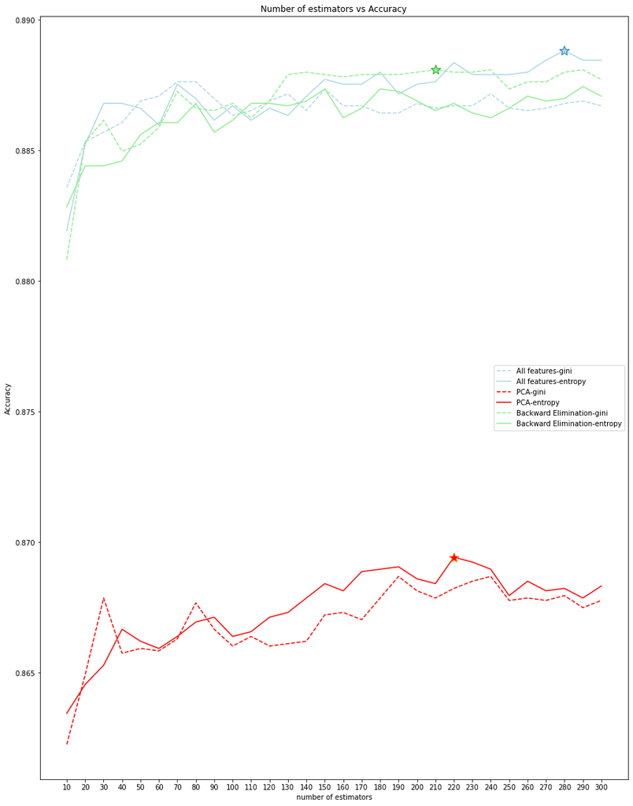

```python
# plot the trend
plt.figure(figsize=(15,20))

# lines
plt.plot(n_est, accuracy_gini_all, color="lightblue", ls="--", label="All features-gini")
plt.plot(n_est, accuracy_entropy_all, color="lightblue", label="All features-entropy")
plt.plot(n_est_entropy_all, max_acc_entropy_all, marker="*", markersize=15, markerfacecolor="lightblue")

plt.plot(n_est, accuracy_gini_pca, color="red", ls="--", label="PCA-gini")
plt.plot(n_est, accuracy_entropy_pca, color="red", label="PCA-entropy")
plt.plot(n_est_entropy_pca, max_acc_entropy_pca, marker="*", markersize=15, markerfacecolor="red")

plt.plot(n_est, accuracy_gini_be, color="lightgreen", ls="--", label="Backward Elimination-gini")
plt.plot(n_est, accuracy_entropy_be, color="lightgreen", label="Backward Elimination-entropy")
plt.plot(n_est_gini_be, max_acc_gini_be, marker="*", markersize=15, markerfacecolor="lightgreen")

# modify plot labels
plt.xticks(n_est)
plt.xlabel("number of estimators")
plt.ylabel("Accuracy")
plt.title("Number of estimators vs Accuracy")
plt.legend(loc="center right")#, bbox_to_anchor=(1.16, 0.5))
plt.savefig("pix/random_forest_accuracies_criterion.png", dpi=200, bbox_inches='tight')
plt.show()
```

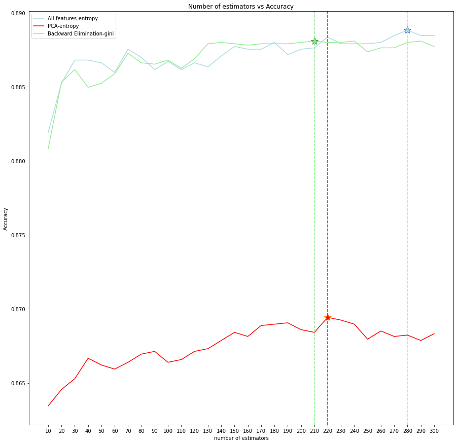

```python
# plot the trend
plt.figure(figsize=(15,15))

# lines
plt.plot(n_est, accuracy_entropy_all, color="lightblue", label="All features-entropy")
plt.plot(n_est_entropy_all, max_acc_entropy_all, marker="*", markersize=15, markerfacecolor="lightblue")
plt.axvline(x=n_est_entropy_all, color='lightblue', ls="--")

plt.plot(n_est, accuracy_entropy_pca, color="red", label="PCA-entropy")
plt.plot(n_est_entropy_pca, max_acc_entropy_pca, marker="*", markersize=15, markerfacecolor="red")
plt.axvline(x=n_est_entropy_pca, color='red', ls="--")

plt.plot(n_est, accuracy_gini_be, color="lightgreen", label="Backward Elimination-gini")
plt.plot(n_est_gini_be, max_acc_gini_be, marker="*", markersize=15, markerfacecolor="lightgreen")
plt.axvline(x=n_est_gini_be, color='lightgreen', ls="--")

# modify plot labels
plt.xticks(n_est)
plt.xlabel("number of estimators")
plt.ylabel("Accuracy")
plt.title("Number of estimators vs Accuracy")
plt.legend(loc="upper left")#, bbox_to_anchor=(1.16, 0.5))
plt.savefig("pix/random_forest_accuracies_number_of_estimators.png", dpi=200, bbox_inches='tight')
plt.show()
```

#### all feature matrix: `n_estimators=280`, `criterion='entropy'`

#### PCA feature matrix: `n_estimators=220`, `criterion='entropy'`

#### backward elimination feature matrix `n_estimators = 210`, `criterion="gini"`

```python
######## all features ##############
print("Random Forest with all features accuracy (n_estmators=280, criterion=entropy):", max(accuracy_entropy_all))

######## PCA ###############
print("Random Forest with 22 features (PCA) accuracy (n_estmators=220, criterion=entropy):", max(accuracy_entropy_pca))

########## backward elimination ######
print("Random Forest with 19 features (backward elimination) accuracy (n_estmators=210, criterion=gini):", max(accuracy_gini_be))
```

```
Random Forest with all features accuracy (n_estmators=280, criterion=entropy): 0.8888174216668198
Random Forest with 22 features (PCA) accuracy (n_estmators=220, criterion=entropy): 0.8694293852797942
Random Forest with 19 features (backward elimination) accuracy (n_estmators=210, criterion=gini): 0.8880823302398235
```

## KNN

```python
# initial run with 31 features
knn_all = KNN(n_neighbors=5)
knn_all.fit(X_train_new, y_train_new)
print("KNN accuracy with all 31 features:", knn_all.score(X_test, y_test))
```

```
KNN accuracy with all 31 features: 0.8240374896627768
```

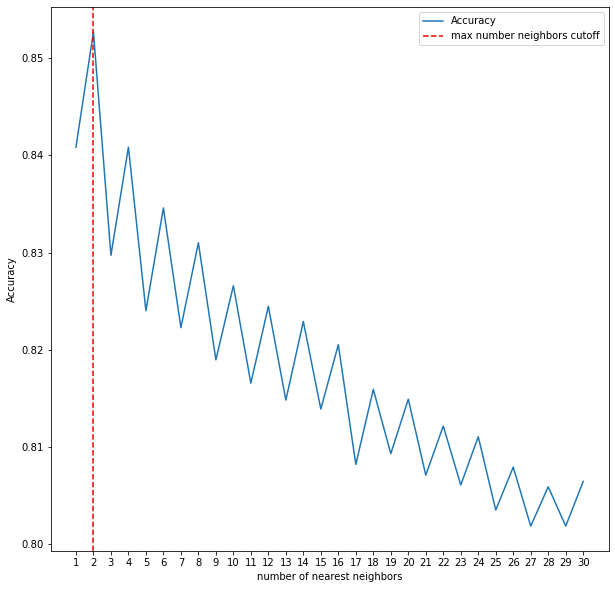

```python
# try different depths to find the best number
n_neighbor = list(range(1, 31))
accuracy = []

for n in n_neighbor:
    knn_all = KNN(n_neighbors=n)
    knn_all.fit(X_train_new, y_train_new)
    accuracy.append(knn_all.score(X_test, y_test))

max_n_neighbor = np.array(accuracy).argmax() + 1
# plot the trend
plt.figure(figsize=(10,10))
plt.plot(n_neighbor, accuracy, label="Accuracy")
plt.axvline(x=max_n_neighbor, color='r', ls="--", label='max number neighbors cutoff')
plt.xticks(n_neighbor)
plt.xlabel("number of nearest neighbors")
plt.ylabel("Accuracy")
plt.legend()
plt.show()
```

### hyper parameter tuning: `n_neighbors`

#### goal is to find the best value of `n_neighbors` that gives the best accuracy

#### all 31 features, pca with 22 and backward elimination with 19

```python
n_neighbor = list(range(1, 21))
accuracy_all = []
accuracy_pca = []
accuracy_be = []

for n in n_neighbor:
    knn_all = KNN(n_neighbors=n)
    knn_all.fit(X_train_new, y_train_new)
    accuracy_all.append(knn_all.score(X_test, y_test))

    knn_pca = KNN(n_neighbors=n)
    knn_pca.fit(X_train_pca, y_train_new)
    accuracy_pca.append(knn_pca.score(X_test_pca, y_test))

    knn_be = KNN(n_neighbors=n)
    knn_be.fit(X_train_be, y_train_new)
    accuracy_be.append(knn_be.score(X_test_be, y_test))

max_nn_all = np.array(accuracy_all).argmax() + 1
max_nn_pca = np.array(accuracy_pca).argmax() + 1
max_nn_be = np.array(accuracy_be).argmax() + 1
```

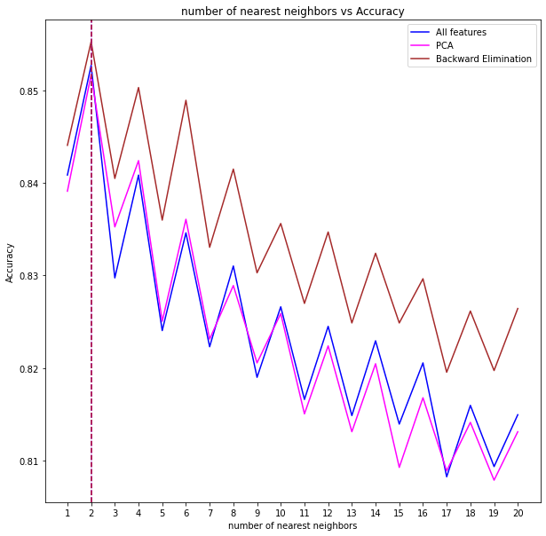

```python
# plot the trend
plt.figure(figsize=(10,10))
plt.plot(n_neighbor, accuracy_all, color="blue", label="All features")
plt.plot(n_neighbor, accuracy_pca, color="magenta", label="PCA")
plt.plot(n_neighbor, accuracy_be, color="brown", label="Backward Elimination")
plt.axvline(x=max_nn_all, color="blue", ls="--")
plt.axvline(x=max_nn_pca, color="magenta", ls="--")
plt.axvline(x=max_nn_be, color="brown", ls="--")
plt.xticks(n_neighbor)
plt.xlabel("number of nearest neighbors")
plt.ylabel("Accuracy")
plt.title("number of nearest neighbors vs Accuracy")
plt.legend(loc="upper right")
plt.savefig("pix/knn_accuracies.png", dpi=200, bbox_inches='tight')
plt.show()
```

#### best value of `n_neighbors` for all feature matrix: 2

#### best value of `n_neighbors` for PCA feature matrix: 2

#### best value of `n_neighbors` for backward elimination feature matrix: 2

```python
######## all features ##############
# accuracy tends to not increase much after n neighbors = 2
knn_all = KNN(n_neighbors=max_nn_all)
knn_all.fit(X_train_new, y_train_new)
print("KNN with all features accuracy (n_neighbors=2):", knn_all.score(X_test, y_test))

######## PCA ###############
# accuracy tends to not increase much after n neighbors = 2
knn_pca = KNN(n_neighbors=max_nn_pca)
knn_pca.fit(X_train_pca, y_train_new)
print("KNN with 22 features (PCA) accuracy (n_neighbors=2):", knn_pca.score(X_test_pca, y_test))

########## backward elimination ######
# accuracy tends to not increase much after n neighbors = 2
knn_be = KNN(n_neighbors=max_nn_be)
knn_be.fit(X_train_be, y_train_new)
print("KNN with 19 features (backward elimination) accuracy (n_neighbors=2):", knn_be.score(X_test_be, y_test))
```

```
KNN with all features accuracy (n_neighbors=2): 0.8527060553156299
KNN with 22 features (PCA) accuracy (n_neighbors=2): 0.8516953046035101
KNN with 19 features (backward elimination) accuracy (n_neighbors=2): 0.8552788753101167
```

## Naive Bayes

### all 31 features

```python
# fit
nb_all = GaussianNB()
nb_all.fit(X_train_new, y_train_new)

print("X_train_new.shape", X_train_new.shape)
print("Naive Bayes accuracy with all 31 features:", nb_all.score(X_test, y_test))
```

```
X_train_new.shape (34146, 31)
Naive Bayes accuracy with all 31 features: 0.4078838555545346
```

### pca 22 features

```python
# fit
nb_pca = GaussianNB()
nb_pca.fit(X_train_pca, y_train_new)

print("X_train_pca.shape", X_train_pca.shape)
print("Naive Bayes accuracy with 22 features:", nb_pca.score(X_test_pca, y_test))
```

```
X_train_pca.shape (34146, 22)
Naive Bayes accuracy with 22 features: 0.524487733161812
```

### backward elimination 19 features

```python
# fit
nb_be = GaussianNB()
nb_be.fit(X_train_be, y_train_new)

print("X_train_pca.shape", X_train_be.shape)
print("Naive Bayes accuracy with 19 features:", nb_be.score(X_test_be, y_test))
```

```
X_train_pca.shape (34146, 19)
Naive Bayes accuracy with 19 features: 0.49600294036570797
```

## Voting Classifier

We will take highest accuracy models from each algorithm and put them in the voting classifier. There will be 3 voting classifier objects per feature matrices we have and compare the results

***Voting Classifier does not take pre-trained models. It just uses each models algorithms to predict its own outcome. we will use the algorithms + hyper parameters from previous models that resulted in the best performance.**

#### results by agorithms:

- Logistic regression Accuracy (with all features): 0.7801157768997519
- logistic regression pca with 22 features 0.7817697326104934
- logistic regression backward elimiation with 19 features: 0.7794725719011302
- **SVM - rbf Accuracy (with all features): 0.8164109161076909 (better accuracy)**
- SVM - poly Accuracy (with all features): 0.8145731875402004
- **SVM - rbf Accuracy (with 22 features): 0.8109896168335937 (better accuracy)**
- SVM - poly Accuracy (with 22 features): 0.8095194339796012
- **SVM - rbf Accuracy (with 19 features): 0.7964715611504181 (better accuracy)**
- SVM - poly Accuracy (with 19 features): 0.7943581732978039
- Decision Tree with all features accuracy **(max_depth=13, criterion=entropy)**: 0.8672241109988055
- Decision Tree with 22 features (PCA) accuracy **(max_depth=29, criterion=entropy)**: 0.8380042267757052
- Decision Tree with 19 features (backward elimination) accuracy **(max_depth=12, criterion=gini)**: 0.8652944960029404
- Random Forest with all features accuracy **(n_estmators=280, criterion=entropy)**: 0.8888174216668198
- Random Forest with 22 features (PCA) accuracy **(n_estmators=220, criterion=entropy)**: 0.8694293852797942
- Random Forest with 19 features (backward elimination) accuracy **(n_estmators=210, criterion=gini)**: 0.8880823302398235
- KNN with all features accuracy **(n_neighbors=2)**: 0.8527060553156299
- KNN with 22 features (PCA) accuracy **(n_neighbors=2)**: 0.8516953046035101
- KNN with 19 features (backward elimination) accuracy **(n_neighbors=2)**: 0.8552788753101167
- Naive Bayes accuracy with all 31 features: 0.4078838555545346
- Naive Bayes accuracy with 22 features: 0.524487733161812
- Naive Bayes accuracy with 19 features: 0.49600294036570797

#### hyper parameters that resulted in best performance per algorithm:

1. **all feature matrix (31 features)**
- Logistic Regression: N/A
- SVM: `kernel=rbf`
- Decision Tree: `max_depth=13`, `criterion=entropy`
- Random Forest: `n_estimators = 280`, `criterion=entropy`
- KNN: `n_neighbprs = 2`
- Naive Bayes: N/A
2. **PCA feature matrix (22 features)**
- Logistic Regression: N/A
- SVM: `kernel=rbf`
- Decision Tree: `max_depth=29`, `criterion=entropy`
- Random Forest: `n_estimators = 220`, `criterion=entropy`
- KNN: `n_neighbprs = 2`
- Naive Bayes: N/A
2. **backward elimination feature matrix (19 features)**
- Logistic Regression: N/A
- SVM: `kernel=rbf`
- Decision Tree: `max_depth=12`, `criterion=gini`
- Random Forest: `n_estimators = 210`, `criterion=gini`
- KNN: `n_neighbprs = 2`
- Naive Bayes: N/A

### What we're trying to to ultimately is to find which of the 3 Voting classifiers peforms the best and analyze the results.

### All feature matrix

build each model with the hyper parameters that resulted in best performance

```python
# models
logit = LogisticRegression(random_state=42)
svm = SVC(kernel="rbf")
tree = DTree(max_depth=13, random_state=42, criterion="entropy")
rf = RF(n_estimators=280, criterion="entropy", random_state=42)
knn = KNN(n_neighbors=2)
nb = GaussianNB()
```

```python
# fit voting classifier
vc_all = VotingClassifier(
    estimators=[
        ('Logistic Regression', logit),
        ('SVM', svm),
        ('Decision Tree', tree),
        ('Random Forest', rf),
        ('KNN', knn),
        ('Naive Bayes', nb)
    ],
    voting='hard')

vc_all.fit(X_train_new, y_train_new)
```

```
VotingClassifier(estimators=[('Logistic Regression',
                              LogisticRegression(random_state=42)),
                             ('SVM', SVC()),
                             ('Decision Tree',
                              DecisionTreeClassifier(criterion='entropy',
                                                     max_depth=13,
                                                     random_state=42)),
                             ('Random Forest',
                              RandomForestClassifier(criterion='entropy',
                                                     n_estimators=280,
                                                     random_state=42)),
                             ('KNN', KNeighborsClassifier(n_neighbors=2)),
                             ('Naive Bayes', GaussianNB())])
```

```python
# make predictions
y_pred = vc_all.predict(X_test)

# classification report
print(classification_report(y_test, y_pred))
```

```
              precision    recall  f1-score   support

           0       0.91      0.90      0.91      7317
           1       0.81      0.82      0.81      3566

    accuracy                           0.88     10883
   macro avg       0.86      0.86      0.86     10883
weighted avg       0.88      0.88      0.88     10883
```

### PCA feature matrix

build each model with the hyper parameters that resulted in best performance

```python
# models
logit = LogisticRegression(random_state=42)
svm = SVC(kernel="rbf")
tree = DTree(max_depth=29, random_state=42, criterion="entropy")
rf = RF(n_estimators=220, criterion="entropy", random_state=42)
knn = KNN(n_neighbors=2)
nb = GaussianNB()
```

```python
# fit voting classifier
vc_pca = VotingClassifier(
    estimators=[
        ('Logistic Regression', logit),
        ('SVM', svm),
        ('Decision Tree', tree),
        ('Random Forest', rf),
        ('KNN', knn),
        ('Naive Bayes', nb)
    ],
    voting='hard')

vc_pca.fit(X_train_pca, y_train_new)
```

```
VotingClassifier(estimators=[('Logistic Regression',
                              LogisticRegression(random_state=42)),
                             ('SVM', SVC()),
                             ('Decision Tree',
                              DecisionTreeClassifier(criterion='entropy',
                                                     max_depth=29,
                                                     random_state=42)),
                             ('Random Forest',
                              RandomForestClassifier(criterion='entropy',
                                                     n_estimators=220,
                                                     random_state=42)),
                             ('KNN', KNeighborsClassifier(n_neighbors=2)),
                             ('Naive Bayes', GaussianNB())])
```

```python
# make predictions
y_pred = vc_pca.predict(X_test_pca)

# classification report
print(classification_report(y_test, y_pred))
```

```
              precision    recall  f1-score   support

           0       0.90      0.90      0.90      7317
           1       0.80      0.80      0.80      3566

    accuracy                           0.87     10883
   macro avg       0.85      0.85      0.85     10883
weighted avg       0.87      0.87      0.87     10883
```

build each model with the hyper parameters that resulted in best performance

```python
# models
logit = LogisticRegression(random_state=42)
svm = SVC(kernel="rbf")
tree = DTree(max_depth=12, random_state=42, criterion="gini")
rf = RF(n_estimators=210, criterion="gini", random_state=42)
knn = KNN(n_neighbors=2)
nb = GaussianNB()
```

```python
# fit voting classifier
final_model = VotingClassifier(
    estimators=[
        ('Logistic Regression', logit),
        ('SVM', svm),
        ('Decision Tree', tree),
        ('Random Forest', rf),
        ('KNN', knn),
        ('Naive Bayes', nb)
    ],
    voting='hard')

final_model.fit(X_train_new, y_train_new)
```

```
VotingClassifier(estimators=[('Logistic Regression',
                              LogisticRegression(random_state=42)),
                             ('SVM', SVC()),
                             ('Decision Tree',
                              DecisionTreeClassifier(max_depth=12,
                                                     random_state=42)),
                             ('Random Forest',
                              RandomForestClassifier(n_estimators=210,
                                                     random_state=42)),
                             ('KNN', KNeighborsClassifier(n_neighbors=2)),
                             ('Naive Bayes', GaussianNB())])
```

```python
# make predictions
y_pred = final_model.predict(X_test)

# classification report
print(classification_report(y_test, y_pred))
```

```
              precision    recall  f1-score   support

           0       0.91      0.90      0.91      7317
           1       0.80      0.82      0.81      3566

    accuracy                           0.87     10883
   macro avg       0.86      0.86      0.86     10883
weighted avg       0.88      0.87      0.87     10883
```

## Feature importance

### For each algorithm, we found which feature matrices are performing well.

### we already use those matrices to fit models and made predictions

### now measure feature importance for each algorithm to find out which variables have significant impact

### this will hopefully answer our hypothesis

### 1. logistic regression

Feature importance is measured by the model coefficients. Positive coefficients indicate that a feature predicts class 1 (cancelled) and negative coefficient indicate a feature that predicts class 0 (not cancelled). The magnitude of coefficients tells us how much of an impact a feature has on predicting each class.

```
no of children, coefficient: 0.05233051932778037
no. of weekend nights, coefficient: 0.16934139919880511
no. of week nights, coefficient: 0.05631999361351955
required car parking space, coefficient: -0.26300683275087483
lead time, coefficient: 1.3859277348507146
repeated guest, coefficient: -0.44987083065148664
no. of previous cancellations, coefficient: 0.07916010434501157
avg price per room, coefficient: 0.55498824378521
no. of special requests, coefficient: -1.1908967492960305
room type 1, coefficient: 0.0711934473275496
room type 5, coefficient: -0.04448961179019101
room type 6, coefficient: -0.07862802087351432
room type 7, coefficient: -0.07791565668525319
meal plan not selected, coefficient: 0.08954796701912283
market segmet aviation, coefficient: 0.09669204031984462
market segmet corporate, coefficient: 0.21706288770165144
market segmet online, coefficient: 0.9177770414955085
arrival season spring, coefficient: 0.04466536527622637
arrival season winter, coefficient: -0.23806484372058187
```

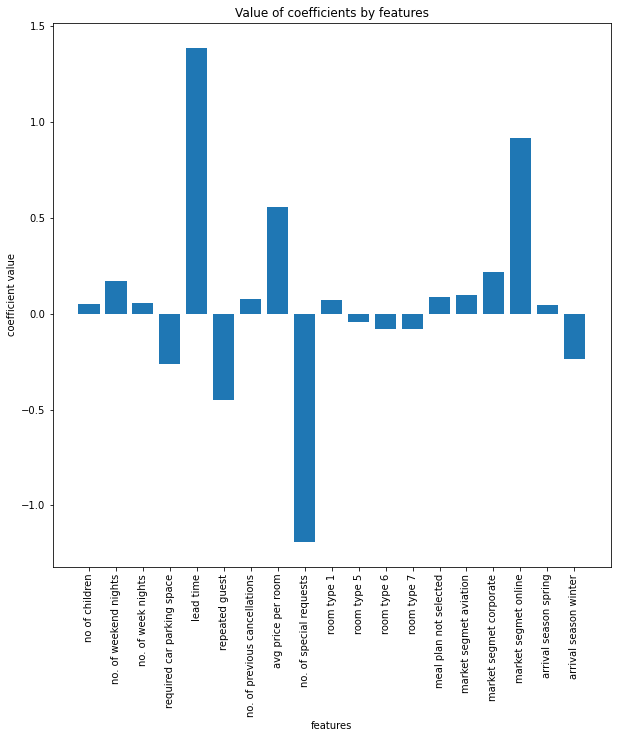

```python
# fit logistic regresion
lr_imp_be = LogisticRegression(random_state = 42)
lr_imp_be.fit(X_train_be, y_train_new)

# feature importance from coefficients
importance_lr = lr_imp_be.coef_[0]

# variable labels
LABELS=[
    "no of children",
    "no. of weekend nights",
    "no. of week nights",
    "required car parking space",
    "lead time",
    "repeated guest",
    "no. of previous cancellations",
    "avg price per room",
    "no. of special requests",
    "room type 1",
    "room type 5",
    "room type 6",
    "room type 7",
    "meal plan not selected",
    "market segmet aviation",
    "market segmet corporate",
    "market segmet online",
    "arrival season spring",
    "arrival season winter"
]

for l, v in zip(LABELS, importance_lr):
    print(f"{l}, coefficient: {v}")

# plot feature importance
num_features = [x for x in range(len(importance_lr))]

plt.figure(figsize=(10,10))
plt.bar(num_features, importance_lr)
plt.xticks(num_features, labels=LABELS, rotation=90)
plt.xlabel("features")
plt.ylabel("coefficient value")
plt.title("Value of coefficients by features")
plt.show()
```

**Lead time coefficient: 1.386; average price per room coefficient: 0.555 -> suggests that they have significant impact on predicting booking status being canceled.**

### 2. Decision Tree

Decision tree classifier calculates feature importance scores which indicates how much impact a feature has on predicting target classes. The values are positive and it simply measures the degree of impact regardless of class labels

```
no of children, importance score: 0.0015704601165149716
no. of weekend nights, importance score: 0.046350146516730355
no. of week nights, importance score: 0.03354017858188298
required car parking space, importance score: 0.011823713135375993
lead time, importance score: 0.42812203683626093
repeated guest, importance score: 0.00048403337931938334
no. of previous cancellations, importance score: 0.00026671465387248793
avg price per room, importance score: 0.12558335961773173
no. of special requests, importance score: 0.1463731241604704
room type 1, importance score: 0.002938455974870048
room type 5, importance score: 0.0006461815190752184
room type 6, importance score: 0.00022837748001254342
room type 7, importance score: 0.00045345855821879254
meal plan not selected, importance score: 0.004705302749420268
market segmet aviation, importance score: 0.00027083472389470006
market segmet corporate, importance score: 0.00261089654174636
market segmet online, importance score: 0.15375077268998386
arrival season spring, importance score: 0.01302257704463499
arrival season winter, importance score: 0.027259375719983815
```

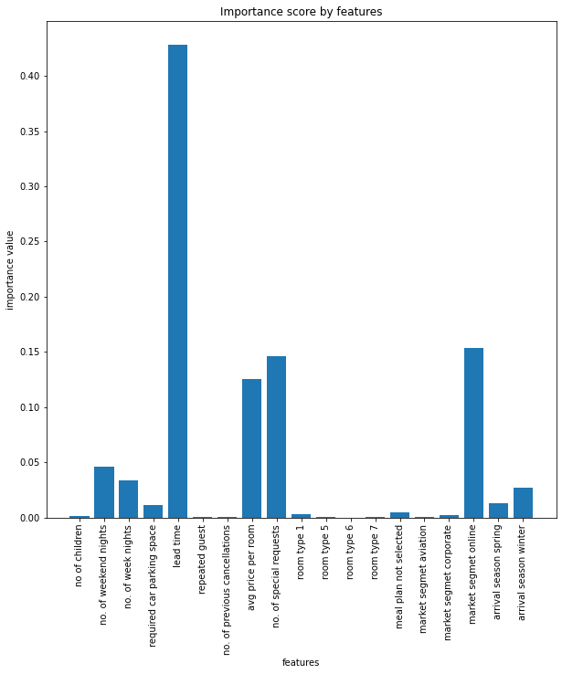

```python
# backward elimination
# max_depth = 12
# criterion = "gini"
# fit decision tree
tree_imp_be = DTree(max_depth=12, criterion="gini", random_state=42)
tree_imp_be.fit(X_train_be, y_train_new)

# feature importance from coefficients
importance_tree = tree_imp_be.feature_importances_

for l, v in zip(LABELS, importance_tree):
    print(f"{l}, importance score: {v}")

# plot feature importance
num_features = [x for x in range(len(importance_tree))]

plt.figure(figsize=(10,10))
plt.bar(num_features, importance_tree)
plt.xticks(num_features, labels=LABELS, rotation=90)
plt.xlabel("features")
plt.ylabel("importance value")
plt.title("Importance score by features")
plt.show()
```

- lead time, importance score: 0.428
- avg price per room, importance score: 0.126

The plot shows that lead time has the highest impact on predicting booking status; average price per room has considerable impact but less compared to lead time.

### 3. Random Forest

Random forest classifier also calculates feature importance score, and it has the same property as those from decision tree classifier.

```
no of children, importance score: 0.007825540816551808
no. of weekend nights, importance score: 0.04784896332670687
no. of week nights, importance score: 0.07600725015698175
required car parking space, importance score: 0.00874297419289266
lead time, importance score: 0.3870662459867617
repeated guest, importance score: 0.004250701137398018
no. of previous cancellations, importance score: 0.0008441571685854963
avg price per room, importance score: 0.2126555472901828
no. of special requests, importance score: 0.12436482004344722
room type 1, importance score: 0.01128068253179451
room type 5, importance score: 0.0014791409561396914
room type 6, importance score: 0.0016454238484885162
room type 7, importance score: 0.00047088405071625756
meal plan not selected, importance score: 0.010738407851011765
market segmet aviation, importance score: 0.0007882222109469575
market segmet corporate, importance score: 0.007521951422543924
market segmet online, importance score: 0.05506617537964843
arrival season spring, importance score: 0.015829342311428206
arrival season winter, importance score: 0.025573569317773458
```

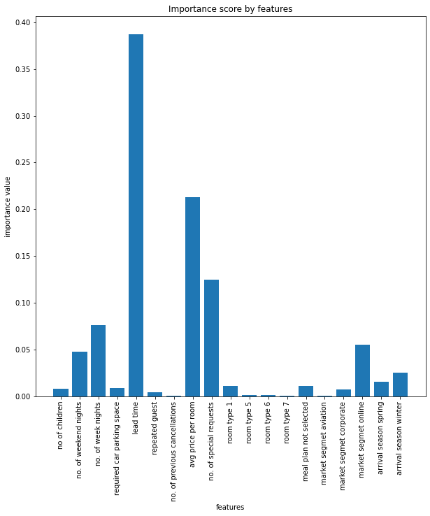

```python
# backward elimination
# n_estimators = 210
# criterion = "gini"
rf_imp_be = RF(n_estimators=210, criterion="gini", random_state=42)
rf_imp_be.fit(X_train_be, y_train_new)

# feature importance from coefficients
importance_rf = rf_imp_be.feature_importances_

for l, v in zip(LABELS, importance_rf):
    print(f"{l}, importance score: {v}")

# plot feature importance
num_features = [x for x in range(len(importance_rf))]

plt.figure(figsize=(10,10))
plt.bar(num_features, importance_rf)
plt.xticks(num_features, labels=LABELS, rotation=90)
plt.xlabel("features")
plt.ylabel("importance value")
plt.title("Importance score by features")
plt.show()
```

- lead time, importance score: 0.387
- avg price per room, importance score: 0.213

The plot shows that lead time has the highest impact on predicting booking status; average price per room has the second highest impact.

```python
!jupyter nbconvert --to html hotel.ipynb
```

```
[NbConvertApp] Converting notebook hotel.ipynb to html
[NbConvertApp] Writing 1997689 bytes to hotel.html
```